# Lab 8

Author

Dom Demas

Published

December 4, 2023

```python
import pandas as pd
from sklearn.model_selection import train_test_split, cross_val_score
from sklearn.preprocessing import StandardScaler, MultiLabelBinarizer
from sklearn.discriminant_analysis import LinearDiscriminantAnalysis as LDA
from sklearn.impute import SimpleImputer
from sklearn.metrics import confusion_matrix
from sklearn.pipeline import make_pipeline
from sklearn.discriminant_analysis import QuadraticDiscriminantAnalysis as QDA
from sklearn.svm import SVC, SVC
from sklearn.multiclass import OneVsRestClassifier
from sklearn.metrics import accuracy_score, confusion_matrix, classification_report
from sklearn.linear_model import LogisticRegression
from sklearn.tree import DecisionTreeClassifier, plot_tree
import matplotlib.pyplot as plt
from sklearn.discriminant_analysis import LinearDiscriminantAnalysis as LDA, QuadraticDiscriminantAnalysis as QDA
from sklearn.neighbors import KNeighborsClassifier
from itertools import combinations

df = pd.read_csv("/content/cannabis_full.csv")


# Create a binary dataset for Sativa and Indica types
binary_df = df[df['Type'].isin(['sativa', 'indica'])]
```

Part One: Binary Classification

```python
# Preprocess the 'Effects' column
mlb_effects = MultiLabelBinarizer()
effects_encoded = mlb_effects.fit_transform(binary_df['Effects'].apply(lambda x: x.split(',')))

# Preprocess the 'Flavor' column, handling missing values
flavor_series = binary_df['Flavor'].apply(lambda x: [] if pd.isna(x) else x.split(','))
mlb_flavor = MultiLabelBinarizer()
flavor_encoded = mlb_flavor.fit_transform(flavor_series)

# Combine encoded features with the original dataset
X = pd.concat([
    binary_df.drop(['Type', 'Strain', 'Effects', 'Flavor'], axis=1),
    pd.DataFrame(effects_encoded, columns=mlb_effects.classes_),
    pd.DataFrame(flavor_encoded, columns=mlb_flavor.classes_)
], axis=1)
y = binary_df['Type']

# Ensure consistent dimensions
X = X.iloc[:len(y), :]

# Impute missing values
imputer = SimpleImputer(strategy='mean')  # You can use 'median' or 'most_frequent' as well
X_imputed = imputer.fit_transform(X)

# Split the data into training and testing sets
X_train, X_test, y_train, y_test = train_test_split(X_imputed, y, test_size=0.2, random_state=42)
```

Q1: LDA

```python
# Create and train LDA model
lda_model = make_pipeline(StandardScaler(), LDA())
lda_scores = cross_val_score(lda_model, X_train, y_train, cv=5, scoring='accuracy')
lda_model.fit(X_train, y_train)
lda_pred = lda_model.predict(X_test)
lda_confusion = confusion_matrix(y_test, lda_pred)

# Display results
print("LDA Cross-validated Accuracy:", lda_scores.mean())
print("Confusion Matrix for LDA:\n", lda_confusion)
```

```
LDA Cross-validated Accuracy: 0.8177985948477751
Confusion Matrix for LDA:
 [[128  15]
 [ 15  70]]
```

Q2: QDA

```python
qda_model = make_pipeline(StandardScaler(), QDA())
qda_scores = cross_val_score(qda_model, X_train, y_train, cv=5, scoring='accuracy')
qda_model.fit(X_train, y_train)
qda_pred = qda_model.predict(X_test)
qda_confusion = confusion_matrix(y_test, qda_pred)

print("QDA Cross-validated Accuracy:", qda_scores.mean())
print("Confusion Matrix for QDA:\n", qda_confusion)
```

```
QDA Cross-validated Accuracy: 0.5138113252867351
Confusion Matrix for QDA:
 [[59 84]
 [25 60]]
```

Q3: SVC

```python
svc_model = make_pipeline(StandardScaler(), SVC())
svc_scores = cross_val_score(svc_model, X_train, y_train, cv=5, scoring='accuracy')
svc_model.fit(X_train, y_train)
svc_pred = svc_model.predict(X_test)
svc_confusion = confusion_matrix(y_test, svc_pred)

print("SVC Cross-validated Accuracy:", svc_scores.mean())
print("Confusion Matrix for SVC:\n", svc_confusion)
```

```
SVC Cross-validated Accuracy: 0.8067795592385757
Confusion Matrix for SVC:
 [[133  10]
 [ 24  61]]
```

Q4: SVM

```python
svm_model = make_pipeline(StandardScaler(), SVC(kernel='poly'))
svm_scores = cross_val_score(svm_model, X_train, y_train, cv=5, scoring='accuracy')
svm_model.fit(X_train, y_train)
svm_pred = svm_model.predict(X_test)
svm_confusion = confusion_matrix(y_test, svm_pred)

print("SVM Cross-validated Accuracy:", svm_scores.mean())
print("Confusion Matrix for SVM:\n", svm_confusion)
```

```
SVM Cross-validated Accuracy: 0.6388638683720651
Confusion Matrix for SVM:
 [[140   3]
 [ 71  14]]
```

Part Two: Natural Multiclass

Q1 Fit a decision tree, plot the final fit, and interpret the results.

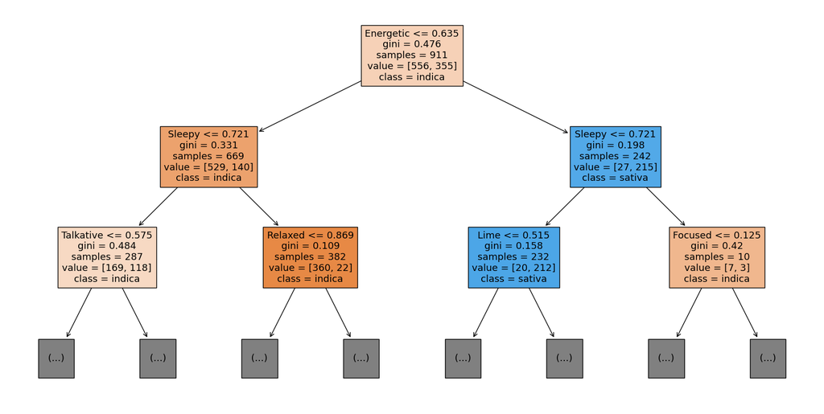

```
Decision Tree Accuracy: 0.8289473684210527
Confusion Matrix for Decision Tree:
 [[123  20]
 [ 19  66]]
Classification Report for Decision Tree:
               precision    recall  f1-score   support

      indica       0.87      0.86      0.86       143
      sativa       0.77      0.78      0.77        85

    accuracy                           0.83       228
   macro avg       0.82      0.82      0.82       228
weighted avg       0.83      0.83      0.83       228
```

```python
# Fit Decision Tree
dt_model = DecisionTreeClassifier(random_state=42)
dt_model.fit(X_train, y_train)

# Plot Decision Tree
plt.figure(figsize=(20, 10))
plot_tree(dt_model, filled=True, feature_names=X.columns, class_names=dt_model.classes_,max_depth = 2)
plt.show()

# Interpret Results
y_pred_dt = dt_model.predict(X_test)
accuracy_dt = accuracy_score(y_test, y_pred_dt)
confusion_matrix_dt = confusion_matrix(y_test, y_pred_dt)
classification_report_dt = classification_report(y_test, y_pred_dt)

print("Decision Tree Accuracy:", accuracy_dt)
print("Confusion Matrix for Decision Tree:\n", confusion_matrix_dt)
print("Classification Report for Decision Tree:\n", classification_report_dt)
```

Q2 Repeat the analyses from Part One for LDA, QDA, and KNN.

```python
# LDA
lda_model = make_pipeline(StandardScaler(), LDA())
lda_scores = cross_val_score(lda_model, X_train, y_train, cv=5, scoring='accuracy')
lda_model.fit(X_train, y_train)
lda_pred = lda_model.predict(X_test)
lda_confusion = confusion_matrix(y_test, lda_pred)

# QDA
qda_model = make_pipeline(StandardScaler(), QDA())
qda_scores = cross_val_score(qda_model, X_train, y_train, cv=5, scoring='accuracy')
qda_model.fit(X_train, y_train)
qda_pred = qda_model.predict(X_test)
qda_confusion = confusion_matrix(y_test, qda_pred)

# KNN
knn_model = make_pipeline(StandardScaler(), KNeighborsClassifier())
knn_scores = cross_val_score(knn_model, X_train, y_train, cv=5, scoring='accuracy')
knn_model.fit(X_train, y_train)
knn_pred = knn_model.predict(X_test)
knn_confusion = confusion_matrix(y_test, knn_pred)

# Display results
print("LDA Cross-validated Accuracy:", lda_scores.mean())
print("Confusion Matrix for LDA:\n", lda_confusion)
print("\nQDA Cross-validated Accuracy:", qda_scores.mean())
print("Confusion Matrix for QDA:\n", qda_confusion)
print("\nKNN Cross-validated Accuracy:", knn_scores.mean())
print("Confusion Matrix for KNN:\n", knn_confusion)
```

```
LDA Cross-validated Accuracy: 0.8177985948477751
Confusion Matrix for LDA:
 [[128  15]
 [ 15  70]]

QDA Cross-validated Accuracy: 0.5138113252867351
Confusion Matrix for QDA:
 [[59 84]
 [25 60]]

KNN Cross-validated Accuracy: 0.7662042875157629
Confusion Matrix for KNN:
 [[119  24]
 [ 22  63]]
```

Q3 Were your metrics better or worse than in Part One? Why? Which categories were most likely to get mixed up, according to the confusion matrices? Why?

Comparing the results between Part One and Part Two:

Decision Tree:

LDA:

Accuracy: The cross-validated accuracy of LDA remains consistent between Part One and Part Two. Confusion Matrix: The confusion matrix for LDA shows that it performed well in correctly identifying both indica and sativa strains.

QDA:

KNN:

Accuracy: KNN is introduced in Part Two with a cross-validated accuracy of 76.62%. Confusion Matrix: The confusion matrix shows reasonable performance, but with some misclassifications for both classes.

Part Three: Multiclass from Binary

Q1 Fit and report metrics for OvR versions of the models. That is, for each of the two model types, create three models:

Indica vs. Not Indica

Sativa vs. Not Sativa

Hybrid vs. Not Hybrid

```python
# Define target categories
categories = ['indica', 'sativa', 'hybrid']

# Create dictionaries to store the trained models
svc_ovr_models = {}

# Loop through categories
for category in categories:
    # Create binary labels for training set
    y_train_category = [1 if label == category else 0 for label in y_train]
    # Create binary labels for testing set
    y_test_category = [1 if label == category else 0 for label in y_test]

    # Initialize SVC model and OneVsRestClassifier
    svc_model = SVC(probability=True, random_state=42)
    svc_ovr_model = OneVsRestClassifier(svc_model)

    # Train the model
    svc_ovr_model.fit(X_train, y_train_category)
    svc_ovr_models[category] = svc_ovr_model

    # Make predictions on the test set
    svc_ovr_pred = svc_ovr_model.predict(X_test)

    # Evaluate the model
    accuracy_svc_ovr = accuracy_score(y_test_category, svc_ovr_pred)
    confusion_matrix_svc_ovr = confusion_matrix(y_test_category, svc_ovr_pred)
    classification_report_svc_ovr = classification_report(y_test_category, svc_ovr_pred)

    # Print metrics for each category
    print(f"Metrics for OvR SVC - {category} vs. Not {category}:")
    print(f"Accuracy: {accuracy_svc_ovr}")
    print(f"Confusion Matrix:\n{confusion_matrix_svc_ovr}")
    print(f"Classification Report:\n{classification_report_svc_ovr}\n")
```

```
Metrics for OvR SVC - indica vs. Not indica:
Accuracy: 0.881578947368421
Confusion Matrix:
[[ 65  20]
 [  7 136]]
Classification Report:
              precision    recall  f1-score   support

           0       0.90      0.76      0.83        85
           1       0.87      0.95      0.91       143

    accuracy                           0.88       228
   macro avg       0.89      0.86      0.87       228
weighted avg       0.88      0.88      0.88       228


Metrics for OvR SVC - sativa vs. Not sativa:
Accuracy: 0.881578947368421
Confusion Matrix:
[[136   7]
 [ 20  65]]
Classification Report:
              precision    recall  f1-score   support

           0       0.87      0.95      0.91       143
           1       0.90      0.76      0.83        85

    accuracy                           0.88       228
   macro avg       0.89      0.86      0.87       228
weighted avg       0.88      0.88      0.88       228


Metrics for OvR SVC - hybrid vs. Not hybrid:
Accuracy: 1.0
Confusion Matrix:
[[228]]
Classification Report:
              precision    recall  f1-score   support

           0       1.00      1.00      1.00       228

    accuracy                           1.00       228
   macro avg       1.00      1.00      1.00       228
weighted avg       1.00      1.00      1.00       228
```

```python
# Create dictionaries to store the trained models
logreg_ovr_models = {}

# Loop through categories
for category in categories:
    # Create binary labels for training set
    y_train_category = [1 if label == category else 0 for label in y_train]
    # Create binary labels for testing set
    y_test_category = [1 if label == category else 0 for label in y_test]

    # Initialize Logistic Regression model and OneVsRestClassifier
    logreg_model = LogisticRegression(max_iter=1000, random_state=42)
    logreg_ovr_model = OneVsRestClassifier(logreg_model)

    # Train the model
    logreg_ovr_model.fit(X_train, y_train_category)
    logreg_ovr_models[category] = logreg_ovr_model

    # Make predictions on the test set
    logreg_ovr_pred = logreg_ovr_model.predict(X_test)

    # Evaluate the model
    accuracy_logreg_ovr = accuracy_score(y_test_category, logreg_ovr_pred)
    confusion_matrix_logreg_ovr = confusion_matrix(y_test_category, logreg_ovr_pred)
    classification_report_logreg_ovr = classification_report(y_test_category, logreg_ovr_pred)

    # Print metrics for each category
    print(f"Metrics for OvR Logistic Regression - {category} vs. Not {category}:")
    print(f"Accuracy: {accuracy_logreg_ovr}")
    print(f"Confusion Matrix:\n{confusion_matrix_logreg_ovr}")
    print(f"Classification Report:\n{classification_report_logreg_ovr}\n")
```

```
Metrics for OvR Logistic Regression - indica vs. Not indica:
Accuracy: 0.8859649122807017
Confusion Matrix:
[[ 70  15]
 [ 11 132]]
Classification Report:
              precision    recall  f1-score   support

           0       0.86      0.82      0.84        85
           1       0.90      0.92      0.91       143

    accuracy                           0.89       228
   macro avg       0.88      0.87      0.88       228
weighted avg       0.89      0.89      0.89       228


Metrics for OvR Logistic Regression - sativa vs. Not sativa:
Accuracy: 0.8859649122807017
Confusion Matrix:
[[132  11]
 [ 15  70]]
Classification Report:
              precision    recall  f1-score   support

           0       0.90      0.92      0.91       143
           1       0.86      0.82      0.84        85

    accuracy                           0.89       228
   macro avg       0.88      0.87      0.88       228
weighted avg       0.89      0.89      0.89       228


Metrics for OvR Logistic Regression - hybrid vs. Not hybrid:
Accuracy: 1.0
Confusion Matrix:
[[228]]
Classification Report:
              precision    recall  f1-score   support

           0       1.00      1.00      1.00       228

    accuracy                           1.00       228
   macro avg       1.00      1.00      1.00       228
weighted avg       1.00      1.00      1.00       228
```

Q2 Which of the six models did the best job distinguishing the target category from the rest? Which did the worst? Does this make intuitive sense?

Best:

Worst:

OvR Logistic Regression - Hybrid vs. Not Hybrid:

Q3 Fit and report metrics for OvO versions of the models. That is, for each of the two model types, create three models:

Indica vs. Sativa

Indica vs. Hybrid

Hybrid vs. Sativa

```python
# OvO for SVC
svc_ovo_models = {}
svc_ovo_combinations = list(combinations(categories, 2))

for combo in svc_ovo_combinations:
    category1, category2 = combo
    # Filter the data for the selected categories
    X_train_ovo = X_train[(y_train == category1) | (y_train == category2)]
    y_train_ovo = y_train[(y_train == category1) | (y_train == category2)]

    X_test_ovo = X_test[(y_test == category1) | (y_test == category2)]
    y_test_ovo = y_test[(y_test == category1) | (y_test == category2)]

    # Convert category labels to binary (0 or 1)
    y_train_ovo = [1 if label == category1 else 0 for label in y_train_ovo]
    y_test_ovo = [1 if label == category1 else 0 for label in y_test_ovo]

    # Check if both classes are present
    if len(set(y_train_ovo)) == 2 and len(set(y_test_ovo)) == 2:
        svc_model = SVC(probability=True, random_state=42)

        svc_model.fit(X_train_ovo, y_train_ovo)
        svc_ovo_models[combo] = svc_model

        svc_ovo_pred = svc_model.predict(X_test_ovo)
        accuracy_svc_ovo = accuracy_score(y_test_ovo, svc_ovo_pred)
        confusion_matrix_svc_ovo = confusion_matrix(y_test_ovo, svc_ovo_pred)
        classification_report_svc_ovo = classification_report(y_test_ovo, svc_ovo_pred)

        print(f"Metrics for OvO SVC - {category1} vs. {category2}:")
        print(f"Accuracy: {accuracy_svc_ovo}")
        print(f"Confusion Matrix:\n{confusion_matrix_svc_ovo}")
        print(f"Classification Report:\n{classification_report_svc_ovo}\n")
    else:
        print(f"Classes missing for OvO SVC - {category1} vs. {category2}")

# Repeat the same process for OvO Logistic Regression
logreg_ovo_models = {}
logreg_ovo_combinations = list(combinations(categories, 2))

for combo in logreg_ovo_combinations:
    category1, category2 = combo
    # Filter the data for the selected categories
    X_train_ovo = X_train[(y_train == category1) | (y_train == category2)]
    y_train_ovo = y_train[(y_train == category1) | (y_train == category2)]

    X_test_ovo = X_test[(y_test == category1) | (y_test == category2)]
    y_test_ovo = y_test[(y_test == category1) | (y_test == category2)]

    # Convert category labels to binary (0 or 1)
    y_train_ovo = [1 if label == category1 else 0 for label in y_train_ovo]
    y_test_ovo = [1 if label == category1 else 0 for label in y_test_ovo]

    # Check if both classes are present
    if len(set(y_train_ovo)) == 2 and len(set(y_test_ovo)) == 2:
        logreg_model = LogisticRegression(max_iter=1000, random_state=42)

        logreg_model.fit(X_train_ovo, y_train_ovo)
        logreg_ovo_models[combo] = logreg_model

        logreg_ovo_pred = logreg_model.predict(X_test_ovo)
        accuracy_logreg_ovo = accuracy_score(y_test_ovo, logreg_ovo_pred)
        confusion_matrix_logreg_ovo = confusion_matrix(y_test_ovo, logreg_ovo_pred)
        classification_report_logreg_ovo = classification_report(y_test_ovo, logreg_ovo_pred)

        print(f"Metrics for OvO Logistic Regression - {category1} vs. {category2}:")
        print(f"Accuracy: {accuracy_logreg_ovo}")
        print(f"Confusion Matrix:\n{confusion_matrix_logreg_ovo}")
        print(f"Classification Report:\n{classification_report_logreg_ovo}\n")
    else:
        print(f"Classes missing for OvO Logistic Regression - {category1} vs. {category2}")
```

```
Metrics for OvO SVC - indica vs. sativa:
Accuracy: 0.881578947368421
Confusion Matrix:
[[ 65  20]
 [  7 136]]
Classification Report:
              precision    recall  f1-score   support

           0       0.90      0.76      0.83        85
           1       0.87      0.95      0.91       143

    accuracy                           0.88       228
   macro avg       0.89      0.86      0.87       228
weighted avg       0.88      0.88      0.88       228


Classes missing for OvO SVC - indica vs. hybrid
Classes missing for OvO SVC - sativa vs. hybrid
Metrics for OvO Logistic Regression - indica vs. sativa:
Accuracy: 0.8859649122807017
Confusion Matrix:
[[ 70  15]
 [ 11 132]]
Classification Report:
              precision    recall  f1-score   support

           0       0.86      0.82      0.84        85
           1       0.90      0.92      0.91       143

    accuracy                           0.89       228
   macro avg       0.88      0.87      0.88       228
weighted avg       0.89      0.89      0.89       228


Classes missing for OvO Logistic Regression - indica vs. hybrid
Classes missing for OvO Logistic Regression - sativa vs. hybrid
```

Q4 Which of the six models did the best job distinguishing at differentiating the two groups? Which did the worst? Does this make intuitive sense?

Best:

Worse:

OvO Logistic Regression - sativa vs. hybrid:

Q5 Suppose you had simply input the full data, with three classes, into the LogisticRegression function. Would this have automatically taken an “OvO” approach or an “OvR” approach?

What about for SVC?

Note: You do not actually have to run code here - you only need to look at sklearn’s documentation to see how these functions handle multiclass input.

By default, scikit-learn’s LogisticRegression uses the “OvR” (One-vs-Rest) strategy for multiclass classification.

For scikit-learn’s SVC, the default behavior is to use the “OvO” (One-vs-One) strategy for multiclass classification.